# MG205: Econometrics Theory and Applications

Topic 2, Parts 3–4: what can a sample estimate tell us?

José Ignacio González Rojas

j.i.gonzalez-rojas@lse.ac.uk

London School of Economics and Political Science

## Eight ideas connect the population to our estimate

1. Population, sample and model
2. Estimand, estimator and estimate
3. Population errors and fitted residuals
4. Assumptions and their roles
5. Unbiasedness
6. Precision and estimated uncertainty
7. Efficiency: the BLUE comparison
8. Consistency

## Population, model and sample

### What are we estimating?

## Population Model vs. Sample Regression

|  | Population | Sample |
| --- | --- | --- |
| **Model** | $Y_i={\color{#004488}\beta_0}+{\color{#004488}\beta_1}X_i+e_i$ | $y_i={\color{#004488}\hat\beta_0}+{\color{#004488}\hat\beta_1}x_i+\hat\varepsilon_i$ |
| **Coefficients** | Fixed parameters: $\beta_0,\beta_1$ | Random estimates: $\hat\beta_0,\hat\beta_1$ |
| **Means** | $\mathbb E[X],\mathbb E[Y]$ | $\bar x=\frac1n\sum_i x_i$, $\bar y=\frac1n\sum_i y_i$ |
| **Variance** | $\operatorname{var}(X)=\mathbb E[(X-\mathbb E[X])^2]$ | $s_x^2=\frac1n\sum_i(x_i-\bar x)^2$ |
| **Covariance** | $\begin{gathered}\operatorname{cov}(X,Y)=\\\mathbb E[(X-\mathbb E[X])(Y-\mathbb E[Y])]\end{gathered}$ | $s_{xy}=\frac1n\sum_i(x_i-\bar x)(y_i-\bar y)$ |

## 1. Running example: study hours and exam grades

We model how simulated students’ exam grades vary with their study hours.

$$\text{grade}_{i}=40+2\,\text{study hours}_{i}+e_{i}.$$

$$\text{study hours}_{i}\sim U[0,15],\qquad e_{i}\sim N(0,8^{2}),$$

with study hours and errors drawn independently.

**Each simulation:** draw 100 new study-hours values and 100 new errors.

This is our running example throughout the lecture.

## An Estimator Converts Data Into Parameter Estimates

### Our study-hours and exam-grade example

| **Component** | **What It Is** | **Example** | **Nature** |
| --- | --- | --- | --- |
| **Estimand** | Parameter | Grade gain per extra study hour: $\beta_1=2$ | Fixed parameter |
| **Estimator** | Statistic (function of the data) to infer the value of an estimand | $\hat{\beta}_1=s_{xy}/s_x^2$ | Formula |
| **Estimate** | Computed value | For example, $\hat\beta_1=1.8$ grade points per hour | Realised number |

**Estimand:** Perfect dish · **Estimator:** Recipe · **Estimate:** What you cooked today

## What’s an estimator?

[figure not shown]

(a) Estimand

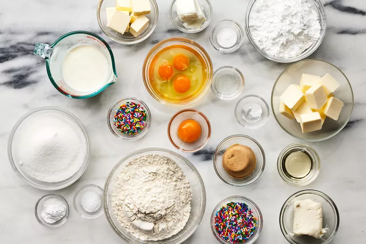

(b) Sample

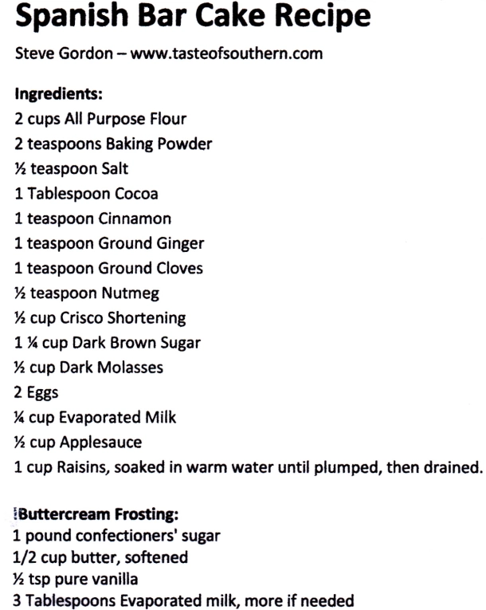

(c) Estimator

[figure not shown]

(d) Estimate

Figure 1: The target, sample, rule and realised result.

## 2. OLS uses sample covariance and sample variance

$$\begin{aligned}
\hat\beta_{1}
&=\frac{\sum_{i=1}^{n}(x_{i}-\bar x)(y_{i}-\bar y)}
{\sum_{i=1}^{n}(x_{i}-\bar x)^{2}}
=\frac{s_{xy}}
{s_x^{2}},\\[0.4em]
\hat\beta_{0}&=\bar y-\hat\beta_{1}\bar x.
\end{aligned}$$

$$s_{xy}=\frac{\sum_i(x_i-\bar x)(y_i-\bar y)}{n},\qquad
s_x^{2}=\frac{\sum_i(x_i-\bar x)^2}{n}>0.$$

## 2. One sample gives one fitted regression

$$\text{grade}_{i}=40+2\,\text{study hours}_{i}+e_{i},\qquad
\widehat{\text{grade}}_{i}=\hat\beta_{0}+\hat\beta_{1}\,\text{study hours}_{i}.$$

[figure not shown]

## 2. Both coefficients have sampling distributions

### Each draw adds one $\hat\beta_{0}$ and one $\hat\beta_{1}$

[figure not shown]

## 3. One sample, two reference lines

### Sample $9{,}533$: selected by a predeclared rule

[figure not shown]

## 3. Zoom in on the same three observations

### Same $y_i$; compare $e_i$ and $\hat\varepsilon_i$

[figure not shown]

## 3. Sums, averages and expectations make different statements

#### Residuals: a fitted identity

$$\sum_{i=1}^{n}\hat\varepsilon_{i}=0.$$

$$\overline{\hat\varepsilon}=0.$$

OLS includes an intercept.

#### Errors: As.4

$$\mathbb{E}[e_{i}]=0.$$

$$\mathbb{E}[\bar e]=\frac{1}{n}\sum_i\mathbb{E}[e_i]=0.$$

An expected average, not a realised zero sum.

Under i.i.d. sampling and finite expectations, $\mathbb{E}[\hat\varepsilon_i]=0$ too. Residual-sum proof Expected-residual proof

## Assumptions and statistical properties

### What does OLS deliver under the model?

## 4. Which assumptions enable what?

| As. | Statement | Identify | Estimate | Infer |
| --- | --- | --- | --- | --- |
| 1 | $Y_{i}={\color{#004488}\beta_{0}}+{\color{#004488}\beta_{1}}X_{i}+e_{i}$ | ✓ | ✓ |  |
| 2 | Independent, identically distributed observations |  | ✓ | ✓ |
| 3 | $\operatorname{var}(X)>0$ | ✓ | ✓ |  |
| 4 | $\mathbb{E}[e_{i}]=0$ | ✓ | ✓ |  |
| 5 | $\mathbb{E}[e_{i}\mid X_{i}]=0$ | ✓ | ✓ |  |
| 6 | $\operatorname{var}(e_{i}\mid X_{i})=\sigma^{2}$ |  |  | ✓ |
| 7 | $e_{i}\mid\mathbf{x}\sim N(0,\sigma^{2})$ |  |  | ✓ |

## 4. As.5 concerns the mean error at each value of $X$

[figure not shown]

## 4. As.4 concerns the overall error mean

[figure not shown]

## 4. The intercept centres errors in population and residuals in samples

#### Population: choose the intercept

$$\beta_0=\mathbb{E}[Y]-\beta_1\mathbb{E}[X].$$

$$\mathbb{E}[e_i]=\mathbb{E}[Y]-\beta_0-\beta_1\mathbb{E}[X]=0.$$

An intercept normalisation, not identification of the slope.

Population proof

#### Sample: fit the intercept

$$\hat\beta_0=\bar y-\hat\beta_1\bar x.$$

$$\overline{\hat\varepsilon}=\bar y-\hat\beta_0-\hat\beta_1\bar x=0.$$

A mechanical OLS identity, not evidence for As.5.

Sample proof

## 5. Centring, spread and convergence are different

| Property | What we ask |
| --- | --- |
| **Unbiasedness** | At this $n$, is the sampling distribution centred on the true parameter? |
| **Precision** | At this $n$, how small is the sampling variance? |
| **Consistency** | As $n$ grows, does the estimate concentrate at the true parameter? |

A narrow distribution can be centred on the wrong value.

## 5. OLS delivers three statistical results

[output not shown]

**Precision:** smaller coefficient variance means less sampling uncertainty.

Error-variance estimate

## 5. Both OLS coefficients are unbiased

### As.1–5; hold the observed $x$-values fixed for the calculation

$$\mathbb{E}[\hat\beta_{1}\mid\mathbf{x}]=\beta_{1},\qquad
\mathbb{E}[\hat\beta_{0}\mid\mathbf{x}]=\beta_{0}.$$

$$\mathbb{E}[\hat\beta_{1}]=\beta_{1},\qquad
\mathbb{E}[\hat\beta_{0}]=\beta_{0}.$$

**Across samples:** positive and negative estimation errors balance.

Slope proof Intercept proof

## 6. More information gives more precise coefficients

### As.1–6; conditional on the observed $x$-values

| Variance | Sample-moment form | Sum form |
| --- | --- | --- |
| $\operatorname{var}(\hat\beta_1\mid\mathbf{x})$ | $\dfrac{\sigma^2}{n}\dfrac{1}{s_x^2}$ | $\dfrac{\sigma^2}{\sum_i(x_i-\bar x)^2}$ |
| $\operatorname{var}(\hat\beta_0\mid\mathbf{x})$ | $\dfrac{\sigma^2}{n}\left(1+\dfrac{\bar x^2}{s_x^2}\right)$ | $\dfrac{\sigma^2 n^{-1}\sum_i x_i^2}{\sum_i(x_i-\bar x)^2}$ |

Less error variation; more observations; more regressor spread.

Slope variance Intercept variance

## 6. A narrower distribution can target the wrong value

[figure not shown]

$$\tilde\beta_1=\tfrac12\hat\beta_1,\qquad
\operatorname{var}(\tilde\beta_1\mid\mathbf{x})
=\tfrac14\operatorname{var}(\hat\beta_1\mid\mathbf{x}).$$

## 6. Sample moments and variance estimation

#### Descriptive sample variance

$$s_x^{2}
=\frac{\sum_i(x_i-\bar x)^2}{n}.$$

Average the squared deviations.

#### If unbiasedness is needed

$$\mathbb E\!\left[\frac{n}{n-1}s_x^2\right]
=\operatorname{var}(X).$$

One fitted sample mean: **one degree**.

#### Regression error-variance estimate

$$\hat\sigma^{2}
=\frac{\sum_i\hat\varepsilon_i^{2}}{n-2}.$$

$$\mathbb{E}[\hat\sigma^{2}\mid\mathbf{x}]=\sigma^{2}.$$

Two fitted regression coefficients: **two degrees**.

## 6. The error-variance estimate also varies across samples

### $\hat\sigma^{2}=\sum_i\hat\varepsilon_i^{2}/(n-2)$

[figure not shown]

## 6. Estimated variance gives an estimated standard error

$$\widehat{\operatorname{var}}(\hat\beta_{1}\mid\mathbf{x})
=\frac{\hat\sigma^{2}}{n}\frac{1}{s_x^{2}}.$$

$$\widehat{\operatorname{se}}(\hat\beta_{1})
=\sqrt{\frac{\hat\sigma^{2}}{ns_x^{2}}}.$$

**Variance:** squared coefficient units. **Standard error:** coefficient units.

## 7. BLUE is a precise statement about efficiency

### Best Linear Unbiased Estimator: As.1–6

$$\operatorname{var}(\hat\beta_{j,\mathrm{OLS}}\mid\mathbf{x})
\leq\operatorname{var}(\tilde\beta_{j}\mid\mathbf{x}),\qquad j=0,1.$$

- **Same target:** $\beta_{j}$
- **Same data and design**
- **Comparison class:** linear in the outcomes and conditionally unbiased

## 8. Increasing sample size distinguishes three estimators

### A common target; compare concentration as $n$ grows

[figure not shown]

## 8. Unbiasedness and consistency answer different questions

| Rule | Finite-sample mean under the model | As $n$ grows |
| --- | --- | --- |
| Full-sample OLS $\hat\beta_{1,n}$ | $\mathbb{E}[\hat\beta_{1,n}]=\beta_{1}$ | Concentrates at $\beta_{1}$ |
| $\dfrac{n}{n+20}\hat\beta_{1,n}$ | Bias $=-\dfrac{20}{n+20}\beta_{1}$ | Concentrates at $\beta_{1}$ |
| OLS using only a fixed ten observations | Unbiased under the same mean conditions | Its sampling spread persists |

Why these properties differ OLS consistency

## Your questions

### Which result should we unpack?

## Choose a result to revisit

Errors and residuals

Slope unbiasedness

Intercept unbiasedness

Slope variance

Intercept variance

Consistency

The three estimator rules

## Five exercises

### Draw, choose, explain and calculate

## Q1: Draw departures from both error assumptions

In $x$–$y$ space, draw a population relation with a **negative reference slope** in which both **As.5 and As.6 fail**.

- Label the reference line, conditional centres and conditional spreads
- Explain each assumption failure separately
- Then choose the matching diagram from **A, B, C and D**

## Q1: Which diagram satisfies the requested departures?

### Dots: conditional means; bars: $\pm1$ SD. Choose A–D.

[figure not shown]

## Q1: A has displaced centres and unequal spreads

### The reference slope is negative

$$\mathbb{E}[e_{i}\mid X_i=x_{L}]<0,\qquad \mathbb{E}[e_{i}\mid X_i=x_{H}]>0.$$

$$\operatorname{var}(e_{i}\mid X_i=x_{L})
>\operatorname{var}(e_{i}\mid X_i=x_{H}).$$

- **A:** both As.5 and As.6 fail
- **B:** displaced centres; equal spreads
- **C:** centres on the line; unequal spreads
- **D:** centres on a horizontal line; unequal spreads

## Q2: Match the top graphs to the bottom graphs

### Explain your pairing: what needs to be comparable?

[figure not shown]

## Q2: Match $1\longrightarrow B$ and $2\longrightarrow A$

### Comparable sample sizes and regressor information

$$\operatorname{var}(\hat\beta_{1}\mid\mathbf{x})
=\frac{\sigma^{2}}{n}\frac{1}{s_x^{2}}.$$

- **Population 1:** greater error spread; wider coefficient distribution **B**
- **Population 2:** smaller error spread; narrower coefficient distribution **A**

**Outcome variation above; sampling variation of estimates below.**

Variance proof

## Q3: Compare fitted slopes across LSE courses

For MG205, MG207 and other LSE courses:

- Observe **all current students’** grades and study hours
- Fit each course’s grade–hours slope
- Plot the slope against the number of students

**Provide an explanation for the shape of the data.**

## Q3: What explains this scatter plot?

### Each course’s fitted grade–hours slope and number of students

[figure not shown]

## Q3: Larger comparable cohorts give more precise slopes

### Comparable relationships, error variance and study-hours variation

#### The observed cohort

- Every current student is observed
- Its fitted slope is a known number
- Compare possible repeated cohorts

#### The sampling explanation

$$\operatorname{var}(\hat\beta_{1}\mid\mathbf{x})
=\frac{\sigma^{2}}{n}\frac{1}{s_x^{2}}.$$

$$n\uparrow\quad\Longrightarrow\quad
\operatorname{var}(\hat\beta_{1}\mid\mathbf{x})\downarrow.$$

Slopes concentrate around their common target.

## Q4: Correlation between $x$ and fitted $y$

Simple OLS **with an intercept**: calculate the sample correlation between $x_{i}$ and the fitted values $\hat y_{i}$.

#### Definitions

$$\hat y_i=\hat\beta_0+\hat\beta_1x_i.$$

$$r(u,v)=\frac{\operatorname{cov}(u,v)}
{\sqrt{\operatorname{var}(u)\operatorname{var}(v)}}.$$

#### Properties

$$\begin{aligned}
\operatorname{cov}(u,a)&=0,\\
\operatorname{cov}(u,v+w)&=\operatorname{cov}(u,v)+\operatorname{cov}(u,w),\\
\operatorname{cov}(u,au)&=a\operatorname{var}(u),\\
\operatorname{var}(au+b)&=a^2\operatorname{var}(u).
\end{aligned}$$

Here $u,v,w$ are observed vectors; $a,b$ are constants across observations.

## Q4: Fitted coefficients are numbers within this sample

#### Covariance

$$\begin{aligned}
&\operatorname{cov}(x,\hat y)\\
&=\operatorname{cov}(x,\hat\beta_0+\hat\beta_1x)\\
&=\operatorname{cov}(x,\hat\beta_0)
+\operatorname{cov}(x,\hat\beta_1x)\\
&=0+\hat\beta_1\operatorname{cov}(x,x)\\
&=\hat\beta_1\operatorname{var}(x).
\end{aligned}$$

#### Variance

$$\begin{aligned}
&\operatorname{var}(\hat y)\\
&=\operatorname{var}(\hat\beta_0+\hat\beta_1x)\\
&=\operatorname{var}(\hat\beta_1x)\\
&=\hat\beta_1^2\operatorname{var}(x).
\end{aligned}$$

#### Correlation

$$\begin{gathered}
r_{x,\hat y}=\frac{\operatorname{cov}(x,\hat y)}
{\sqrt{\operatorname{var}(x)\operatorname{var}(\hat y)}}\\
=\frac{\hat\beta_1\operatorname{var}(x)}
{\sqrt{\hat\beta_1^2[\operatorname{var}(x)]^2}}\\
=\frac{\hat\beta_1\operatorname{var}(x)}
{|\hat\beta_1|\operatorname{var}(x)}
=\frac{\hat\beta_1}{|\hat\beta_1|}.
\end{gathered}$$

$\operatorname{var}(x)>0:\quad \hat\beta_1>0\Rightarrow +1;\quad \hat\beta_1<0\Rightarrow -1;\quad \hat\beta_1=0\Rightarrow\text{undefined}.$

## Q5: Does log sales imply biased OLS estimates?

OLS model, for positive sales:

$$\text{research and development expenditure}_{i}
=\beta_{0}+\beta_{1}\log(\text{sales}_{i})+e_{i}.$$

Discuss the claim: “OLS estimates must be biased because the population model is not linear. Assumption 1 therefore fails.”

## Q5: Log sales is a regressor, not a coefficient

### $x_{i}=\log(\text{sales}_{i})$: linear in $\beta_{0}$ and $\beta_{1}$

[figure not shown]

## Q5: Separate calculation, parameter linearity and unbiasedness

- Varying log sales: **OLS can be calculated**
- Coefficient linearity: **As.1 can hold**
- Appropriate model and sampling conditions: **unbiasedness**

$$\mathbb{E}[e_{i}\mid\log(\text{sales}_{i})]=0$$

**Taking logs alone does not establish this expectation.**

## Next class: prepare the empirical exercise

Bring the exercise questions, your code and the parts you want to discuss.

## References

MG205 Topic 2 course materials: lecture, practice questions and solutions.

Hansen (2022)

Hansen, Bruce E. 2022. *Econometrics*. Princeton University Press.

## Optional proofs

### Open a result, work through its steps, then return

## An intercept can normalise the population error mean

For any given slope $\beta_1$ and finite population means, choose

$$\beta_0=\mathbb{E}[Y]-\beta_1\mathbb{E}[X],\qquad
e_i=Y_i-\beta_0-\beta_1X_i.$$

$$\begin{aligned}
\mathbb{E}[e_i]
&=\mathbb{E}[Y]-\beta_0-\beta_1\mathbb{E}[X]\\
&=\mathbb{E}[Y]-\bigl(\mathbb{E}[Y]-\beta_1\mathbb{E}[X]\bigr)
-\beta_1\mathbb{E}[X]\\
&=0.
\end{aligned}$$

This chooses the intercept’s normalisation; it does not identify $\beta_1$.

Same-data illustration Back to As.4

## Recentring the error leaves the grades unchanged

[figure not shown]

Back to the population proof Back to As.4

## The fitted intercept makes the residual mean zero

The intercept first-order condition is

$$\begin{aligned}
0&=\left.\frac{\partial}{\partial b_0}
\sum_i(y_i-b_0-b_1x_i)^2\right|_{b_0=\hat\beta_0,\,b_1=\hat\beta_1}\\
&=-2\sum_i(y_i-\hat\beta_0-\hat\beta_1x_i)
=-2\sum_i\hat\varepsilon_i.
\end{aligned}$$

$$\sum_i\hat\varepsilon_i=0
\quad\Longrightarrow\quad
\overline{\hat\varepsilon}=\bar y-\hat\beta_0-\hat\beta_1\bar x=0.$$

No zero-conditional-mean assumption is needed.

Expected-residual proof Back to As.4 Back to errors and residuals

## Expected residuals are zero under i.i.d. sampling

OLS with an intercept gives $\sum_i\hat\varepsilon_i=0$. Relabelling i.i.d. observations only relabels their residuals. With finite expectations, they have the same expected value, say $m$:

$$\mathbb{E}[\hat\varepsilon_1]=\cdots
=\mathbb{E}[\hat\varepsilon_n]=m.$$

$$0=\mathbb{E}\!\left[\sum_i\hat\varepsilon_i\right]
=\sum_i\mathbb{E}[\hat\varepsilon_i]=nm
\quad\Longrightarrow\quad m=0.$$

$$\mathbb{E}[\hat\varepsilon_i]=0,\qquad
\mathbb{E}[\overline{\hat\varepsilon}]=\mathbb{E}[0]=0.$$

Residual-sum proof Back to errors and residuals

## Substitute the model into the familiar slope rule

$$\begin{aligned}
\hat\beta_{1}
&=\frac{s_{x,\beta_0+\beta_1x+e}}
{s_x^{2}}\\
&=\beta_1+\frac{s_{xe}}
{s_x^{2}}.
\end{aligned}$$

$$\begin{aligned}
ns_{xe}
&=\sum_i(x_i-\bar x)(e_i-\bar e)\\
&=\sum_i(x_i-\bar x)e_i-\bar e\underbrace{\sum_i(x_i-\bar x)}_{0}.
\end{aligned}$$

$$\hat\beta_1-\beta_1
=\frac{\sum_i(x_i-\bar x)e_i}{ns_x^{2}}.$$

Continue to unbiasedness Back to the result

## The slope is unbiased, step by step

### Hold observed $x$-values fixed for this calculation

$$\begin{aligned}
\hat\beta_1-\beta_1
&=\frac{\sum_i(x_i-\bar x)e_i}{ns_x^{2}},\\[0.4em]
\mathbb{E}[\hat\beta_1-\beta_1\mid\mathbf{x}]
&=\frac{\sum_i(x_i-\bar x)\mathbb{E}[e_i\mid\mathbf{x}]}
{ns_x^{2}}\\
&=0,\\[0.4em]
\mathbb{E}[\hat\beta_1-\beta_1]
&=\mathbb{E}\!\left[\mathbb{E}[\hat\beta_1-\beta_1\mid\mathbf{x}]\right]=0.
\end{aligned}$$

Model-substitution steps Back to unbiasedness

## The intercept is unbiased without assuming slope unbiasedness

$$\bar y=\beta_0+\beta_1\bar x+\bar e,\qquad
\hat\beta_0-\beta_0=\bar e-\bar x(\hat\beta_1-\beta_1).$$

$$\begin{aligned}
\mathbb{E}[\hat\beta_0-\beta_0\mid\mathbf{x}]
&=\frac1n\sum_i \mathbb{E}[e_i\mid\mathbf{x}]\\
&\quad-\frac{\bar x}{ns_x^{2}}
\sum_i(x_i-\bar x)\mathbb{E}[e_i\mid\mathbf{x}]\\
&=0-0=0,\\[0.3em]
\mathbb{E}[\hat\beta_0-\beta_0]&=\mathbb{E}[0]=0.
\end{aligned}$$

Slope’s algebraic identity Back to unbiasedness

## The slope variance follows from variance rules

### Independent observations and common conditional error variance

$$\begin{aligned}
\operatorname{var}(\hat\beta_1\mid\mathbf{x})
&=\frac{\operatorname{var}\!\left(\sum_i(x_i-\bar x)e_i\mid\mathbf{x}\right)}
{[ns_x^{2}]^2}\\
&=\frac{\sum_i(x_i-\bar x)^2\sigma^2}
{[ns_x^{2}]^2}\\
&=\frac{\sigma^2ns_x^{2}}
{[ns_x^{2}]^2}
=\frac{\sigma^2}{n}\frac{1}{s_x^{2}}.
\end{aligned}$$

Back to precision

## The mean error and slope error have zero covariance

$$\operatorname{var}(\bar e\mid\mathbf{x})
=\frac1{n^2}\sum_i\operatorname{var}(e_i\mid\mathbf{x})=\frac{\sigma^2}{n}.$$

$$\begin{aligned}
\operatorname{cov}(\bar e,\hat\beta_1-\beta_1\mid\mathbf{x})
&=\frac{\sum_i\sum_j(x_j-\bar x)\operatorname{cov}(e_i,e_j\mid\mathbf{x})}
{n^2s_x^{2}}\\
&=\frac{\sigma^2\sum_j(x_j-\bar x)}
{n^2s_x^{2}}=0.
\end{aligned}$$

Return to intercept variance

## The intercept variance includes a covariance term

$$\hat\beta_0-\beta_0=\bar e-\bar x(\hat\beta_1-\beta_1).$$

$$\begin{aligned}
\operatorname{var}(\hat\beta_0\mid\mathbf{x})
&=\operatorname{var}(\bar e\mid\mathbf{x})
+\bar x^2\operatorname{var}(\hat\beta_1\mid\mathbf{x})\\
&\quad-2\bar x\operatorname{cov}(\bar e,\hat\beta_1-\beta_1\mid\mathbf{x})\\
&=\frac{\sigma^2}{n}
+\frac{\bar x^2\sigma^2}{ns_x^{2}}-0\\
&=\frac{\sigma^2}{n}\left(1+\frac{\bar x^2}{s_x^{2}}\right).
\end{aligned}$$

Covariance cancellation Back to precision

## OLS consistency follows from sample moments

### Independent sampling, finite moments and positive population variance

$$\begin{aligned}
s_{xy}&\xrightarrow{p}\operatorname{cov}(X,Y),\\
s_x^{2}&\xrightarrow{p}\operatorname{var}(X)>0,\\
\hat\beta_{1,n}
&=\frac{s_{xy}}{s_x^{2}}
\xrightarrow{p}\frac{\operatorname{cov}(X,Y)}{\operatorname{var}(X)}
=\beta_1,\\
\hat\beta_{0,n}&=\bar y-\hat\beta_{1,n}\bar x
\xrightarrow{p}\mathbb{E}[Y]-\beta_1\mathbb{E}[X]=\beta_0.
\end{aligned}$$

Back to the simulation Population covariance step

## The population covariance identifies the model slope

For the population model $Y=\beta_0+\beta_1X+e$:

$$\mathbb{E}[X e]=\mathbb{E}\!\left[X\mathbb{E}[e\mid X]\right]=0,\qquad \mathbb{E}[e]=0.$$

$$\begin{aligned}
\operatorname{cov}(X,e)
&=\mathbb{E}[X e]-\mathbb{E}[X]\mathbb{E}[e]=0,\\
\operatorname{cov}(X,Y)
&=\operatorname{cov}(X,\beta_0+\beta_1X+e)\\
&=\beta_1\operatorname{var}(X).
\end{aligned}$$

Return to consistency

## Bias and concentration can move differently

$$\begin{aligned}
\mathbb{E}\!\left[\frac{n}{n+20}\hat\beta_{1,n}\right]-\beta_1
&=-\frac{20}{n+20}\beta_1,\\
\frac{n}{n+20}\hat\beta_{1,n}-\beta_1
&=\frac{n}{n+20}(\hat\beta_{1,n}-\beta_1)
-\frac{20}{n+20}\beta_1\xrightarrow{p}0.
\end{aligned}$$

**Fixed-ten rule:** adding unused observations leaves the estimator unchanged.

$$\Pr\!\left(|\tilde\beta_{1,n}-\beta_1|>\delta\right)
=\Pr\!\left(|\tilde\beta_{1,10}-\beta_1|>\delta\right)>0$$

for some $\delta>0$ when the fixed-subsample estimator has nonzero sampling spread.

Back to the three rules